# Inferência por reamostragem e permutação

Nazareno Andrade

16 de abril de 2016

# Significância

## Exemplo 1: moeda

Jogamos 17 vezes, foi 2 vezes apenas cara. Temos evidência de que essa moeda é injusta?

Decisão: o acontecido é improvável o suficiente numa moeda justa para que digamos que esta moeda é injusta?

Hipótese: a moeda é injusta. Hipótese nula: a moeda não é injusta.

Quantas vezes conseguimos 15 ou mais coroas se jogamos a moeda muitas muitas vezes?

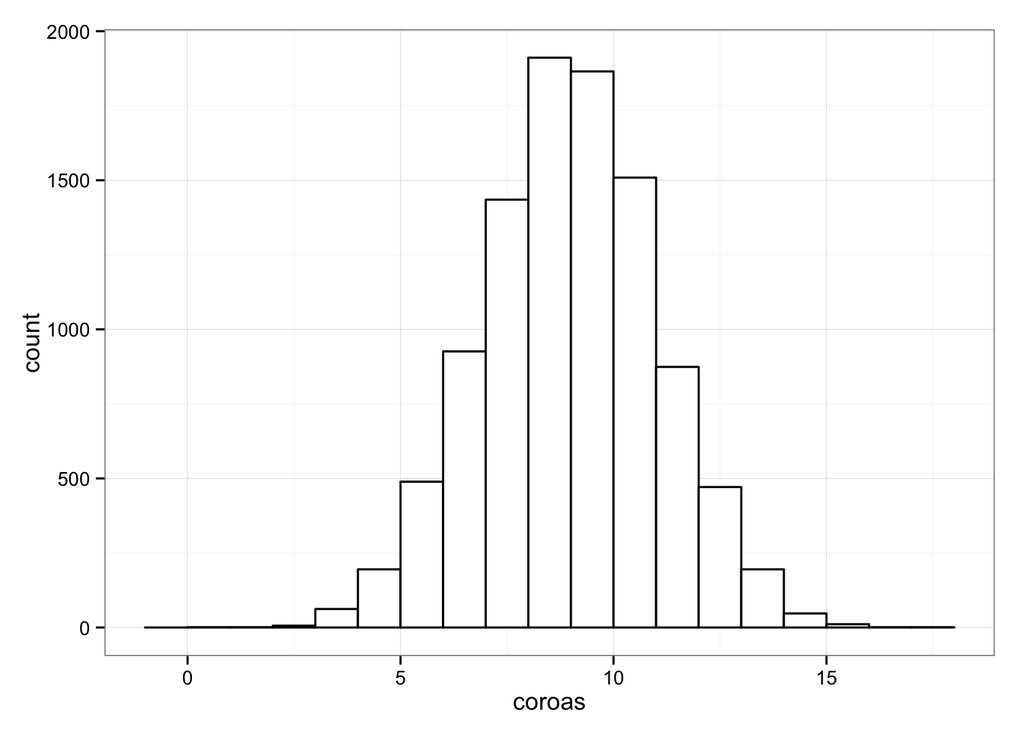

```r
lancamentos = 17
observado_coroas = 15

probabilidade_coroa = .5

numero_jogadas = 10000

# Retorna o numero de vezes que um evento de
# probabilidade p aconteceu em n tentativas
repete_experimento = function(p, n){
  sorteios = runif(n, min = 0, max = 1)
  return(length(which(sorteios < p)))
}

num_experimentos = 1e4
experimentos = data_frame(i = 1:num_experimentos)
experimentos = experimentos %>%
  rowwise() %>%
  mutate(coroas = repete_experimento(probabilidade_coroa, lancamentos))

ggplot(experimentos, aes(x = coroas)) +
  geom_histogram(binwidth = 1, colour = "black", fill = "white")
```

```r
quantas_aconteceram = length(which(experimentos$coroas >= observado_coroas))
probabilidade = quantas_aconteceram / num_experimentos

quantas_aconteceram
```

```
## [1] 13
```

```r
probabilidade
```

```
## [1] 0.0013
```

Em 13 de 10^{4} rodadas observamos 15 ou mais coroas em 17 lançamentos. A probabilidade de 15 acontecer aleatoriamente é portanto 0.0013.

## Exemplo 2: tratamento

Dados:

```
## stat_bin: binwidth defaulted to range/30. Use 'binwidth = x' to adjust this.
## stat_bin: binwidth defaulted to range/30. Use 'binwidth = x' to adjust this.
```

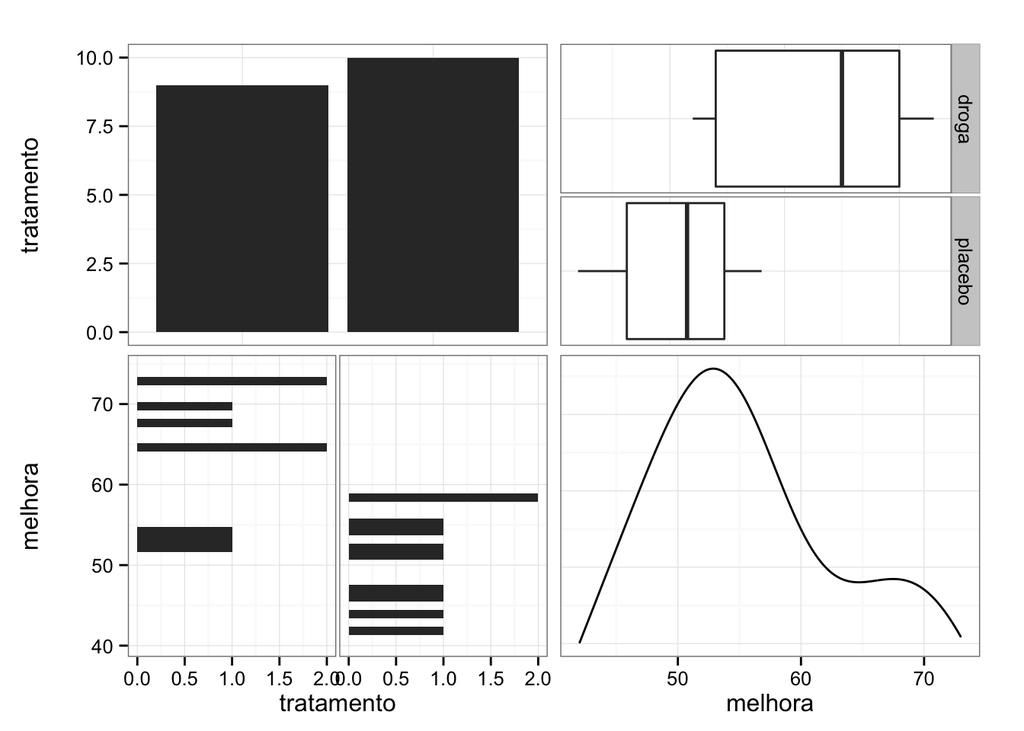

```r
experimento = data_frame(tratamento= "placebo",
                         melhora = c(54, 51, 58, 44, 55, 52, 42, 47, 58, 46))
experimento = rbind(experimento, data_frame(tratamento = "droga", melhora = c(54, 73, 53, 70, 73, 68, 52, 65, 65)))
experimento$tratamento = factor(experimento$tratamento)
ggpairs(experimento)
```

```r
# melhora observada como média:
medias = experimento %>%
  group_by(tratamento) %>%
  summarise(media = mean(melhora))
melhora_media = medias[1, "media"] - medias[2, "media"]
print(paste("Melhora na média observada:", melhora_media))
```

```
## [1] "Melhora na média observada: 12.9666666666667"
```

Pergunta: houve uma melhora significativamente maior nos pacientes que usaram a droga?

Resposta: quantas vezes aconteceria se a relação entre tratamento e melhora fosse completamente aleatória?

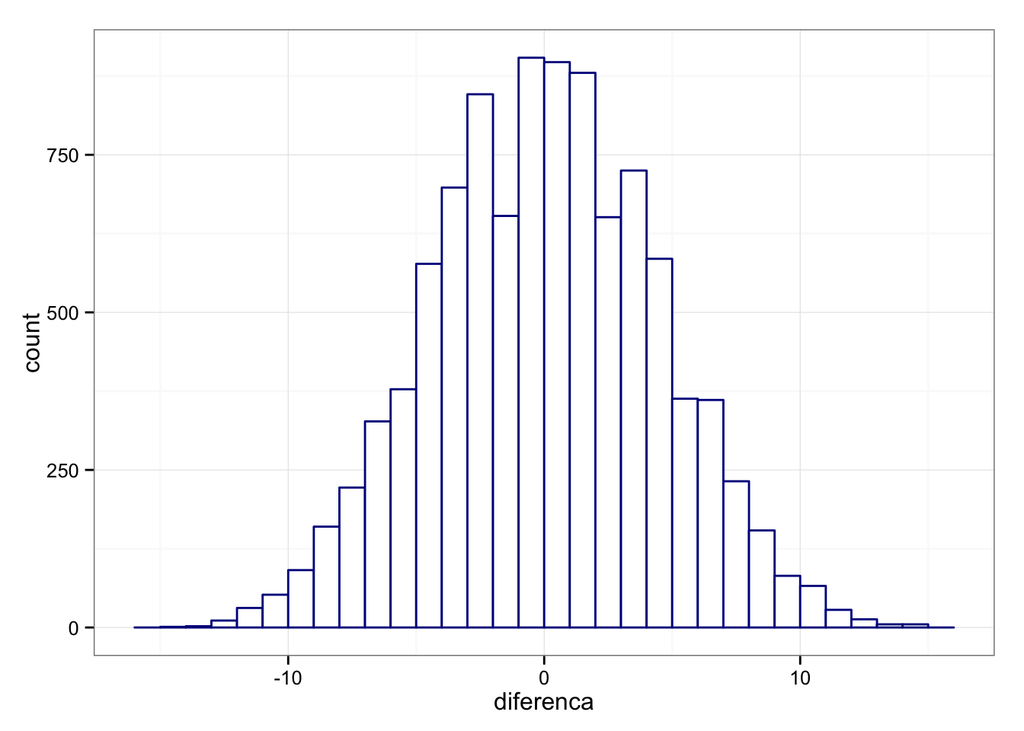

```r
# Retorna a diferença nas médias entre o grupos de y
# nos índices com valor de x igual a baseline após embaralhar x.
repete_experimento_de_diff = function(x, y, baseline){
  embaralhado = x[sample(NROW(x))]
  baseline_mean = mean(y[which(embaralhado == baseline)])
  other_mean = mean(y[which(embaralhado != baseline)])
  return(other_mean - baseline_mean)
}

num_experimentos = 10000
experimentos = data_frame(i = 1:num_experimentos)
experimentos = experimentos %>%
  rowwise() %>%
  mutate(diferenca = repete_experimento_de_diff(experimento$tratamento,
                                                experimento$melhora,
                                                "placebo"))

ggplot(experimentos, aes(x = diferenca)) +
  geom_histogram(binwidth = 1, colour = "darkblue", fill = "white")
```

```r
summary(experimentos)
```

```
##        i           diferenca
##  Min.   :    1   Min.   :-14.47778
##  1st Qu.: 2501   1st Qu.: -3.07778
##  Median : 5000   Median :  0.08889
##  Mean   : 5000   Mean   :  0.02532
##  3rd Qu.: 7500   3rd Qu.:  3.04444
##  Max.   :10000   Max.   : 14.65556
```

```r
quantas_aconteceram = length(which(experimentos$diferenca >= melhora_media$media))
probabilidade = quantas_aconteceram / num_experimentos

quantas_aconteceram
```

```
## [1] 11
```

```r
probabilidade
```

```
## [1] 0.0011
```

Mesma lógica pode ser aplicada para a mediana. Para o 3o quartil, para o desvio padrão… (Mas não para tudo, infelizmente)

# Relevância / importância

A diferença é significativa. Mas ela é importante / relevante?

Para responder, precisamos entender que diferença esperamos se repetirmos o experimento. Construir uma estimativa do intervalo onde esperamos que a diferença esteja em x% repetições. Isso é, um Intervalo de Confiança com uma confiança x.

Para fazer isso, precisamos de várias amostras vindas da mesma população de pessoas que tomaram placebo e tomaram melhoras. E aqui é o pulo do gato: é possível estimar essa população usando a própria amostra. Isso se chama bootstrapping.

Importante: Bootstrapping precisa de um pouco mais de dados do que temos neste exemplo. Aqui usamos os mesmos apenas pra simplificar a apresentação.

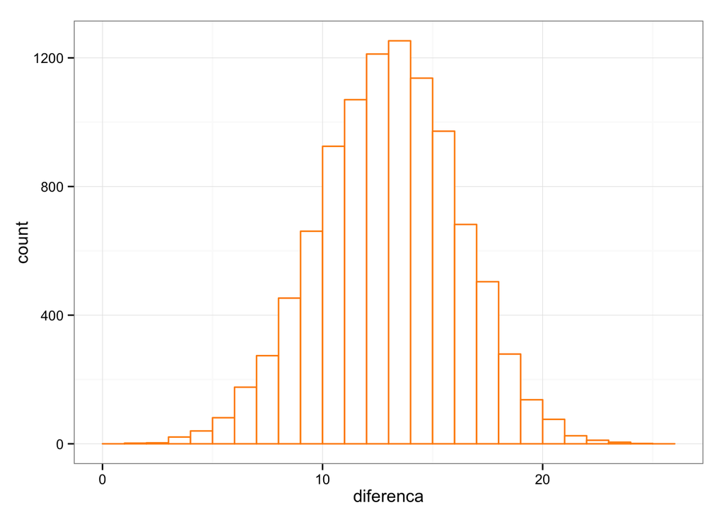

```r
repeticoes = 10000 # pelo menos 1000, mas mais não faz mal.

exp_com_bootstrap <- function(x, y){
  boot_x <- sample(x, size = NROW(x), replace = TRUE) # aqui é o bootstrap
  boot_y <- sample(y, size = NROW(y), replace = TRUE) # de novo!
  return(mean(boot_x) - mean(boot_y))
}

experimentos = data_frame(i = 1:repeticoes)
experimentos = experimentos %>%
  rowwise() %>%
  mutate(diferenca = exp_com_bootstrap(experimento[experimento$tratamento != "placebo",]$melhora,
                                       experimento[experimento$tratamento == "placebo",]$melhora))

ggplot(experimentos, aes(x = diferenca)) +
  geom_histogram(binwidth = 1, colour = "darkorange", fill = "white")
```

```r
summary(experimentos)
```

```
##        i           diferenca
##  Min.   :    1   Min.   : 1.456
##  1st Qu.: 2501   1st Qu.:10.844
##  Median : 5000   Median :13.056
##  Mean   : 5000   Mean   :13.002
##  3rd Qu.: 7500   3rd Qu.:15.178
##  Max.   :10000   Max.   :24.178
```

```r
# IC com 90%:
alpha = .1
quantile(experimentos$diferenca,
         probs = c(.05, .95))
```

```
##        5%       95%
##  7.677778 18.089444
```

```r
quantile(experimentos$diferenca, probs = c(alpha/2, 1 - alpha/2))
```

```
##        5%       95%
##  7.677778 18.089444
```

```r
# IC com 95%:
alpha = .05
quantile(experimentos$diferenca, probs = c(alpha/2, 1 - alpha/2))
```

```
##      2.5%     97.5%
##  6.655556 19.011111
```

# Sobre o uso de reamostragem (ressampling) e bootstraping

Estimar o intervalo de confiança via bootstrap não é recomendado para amostras pequenas (n < 100). Nesses casos, testes de significância com permutação são mais adequados. Eles funcionam para n >= 3 de cada categoria.

Significância complementa o cálculo de ICs nessa abordagem. Por exemplo, pense no caso onde há uma observação no grupo 1 e uma no grupo 2. Há IC mas não há significância.

Não use bootstrap para estimar o máximo, mínimo ou o n-ésimo maior/menor valor. Mas use para percentis.

Como sempre, cuidado com outliers.

# Com um pacote

```r
# install.packages("resample")
library(resample)
permutationTest2(experimento, mean(melhora), treatment = tratamento)
```

```
## Call:
## permutationTest2(data = experimento, statistic = mean(melhora),
##     treatment = tratamento)
## Replications: 9999
## Two samples, sample sizes are 9 10
##
## Summary Statistics for the difference between samples 1 and 2:
##                              Observed        Mean Alternative PValue
## mean(melhora): droga-placebo 12.96667 -0.04027403   two.sided  2e-04
```

```r
b = bootstrap(experimento$melhora, mean)
CI.percentile(b, probs = c(.025, .975))
```

```
##          2.5%    97.5%
## mean 52.31579 61.60719
```

```r
b2 = bootstrap2(experimento, mean(melhora), treatment = tratamento)
CI.percentile(b2, probs = c(.025, .975))
```

```
##                                 2.5%    97.5%
## mean(melhora): droga-placebo 5.15012 20.48605
```

```r
b2.median = bootstrap2(experimento, median(melhora), treatment = tratamento)
CI.percentile(b2.median, probs = c(.025, .975))
```

```
##                                2.5% 97.5%
## median(melhora): droga-placebo   -1    25
```

# Estatísticas via reamostragem e bootstrapping vs. métodos clássicos

Um exemplo com muitos dados:

```r
lastfm = read.csv("dados/experimento-lastfm.csv")
str(lastfm)
```

```
## 'data.frame':    11989 obs. of  15 variables:
##  $ user          : Factor w/ 11989 levels "__eNeRGy__","__Tiago__",..: 39 40 41 42 43 44 45 46 47 48 ...
##  $ ecletic       : num  1159 3440 1611 697 1660 ...
##  $ clusters_total: int  37 155 68 37 72 93 163 150 88 132 ...
##  $ clusters      : int  19 57 25 13 31 37 64 59 27 58 ...
##  $ media_pop     : num  5.54 4.73 5.8 5 5.8 ...
##  $ mediana_pop   : num  5.66 4.73 5.9 5.21 5.87 ...
##  $ dp_pop        : num  0.685 0.882 0.617 0.869 0.545 ...
##  $ news          : int  38 32 24 36 28 25 30 28 14 22 ...
##  $ news_total    : int  38 32 24 36 28 25 30 28 14 22 ...
##  $ old           : int  116 130 10 46 128 95 228 53 46 118 ...
##  $ old_total     : int  119 141 13 71 133 167 256 63 52 125 ...
##  $ count_sim     : num  0.1555 0.0748 -0.1232 0.0842 0.0373 ...
##  $ tempo_sim     : num  0.2084 -0.02033 -0.04348 -0.00161 0.1631 ...
##  $ count_pop     : num  0.2692 0.1314 -0.1667 0.0937 0.0952 ...
##  $ tempo_pop     : num  0.083 -0.1423 -0.1159 0.1301 0.0902 ...
```

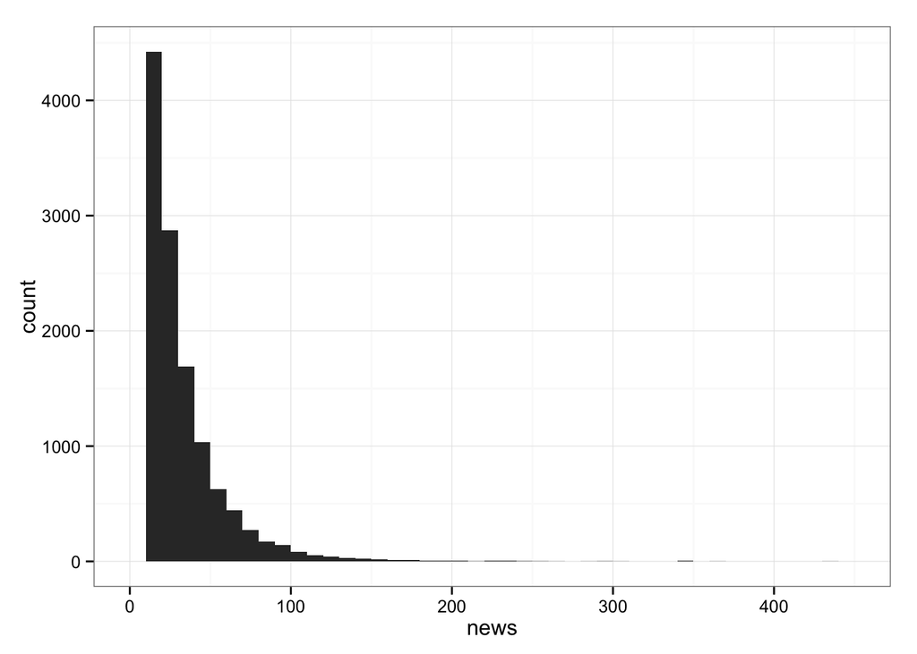

```r
lastfm = select(lastfm, news, ecletic)

lastfm %>% ggplot(aes(news)) + geom_histogram(binwidth = 10)
```

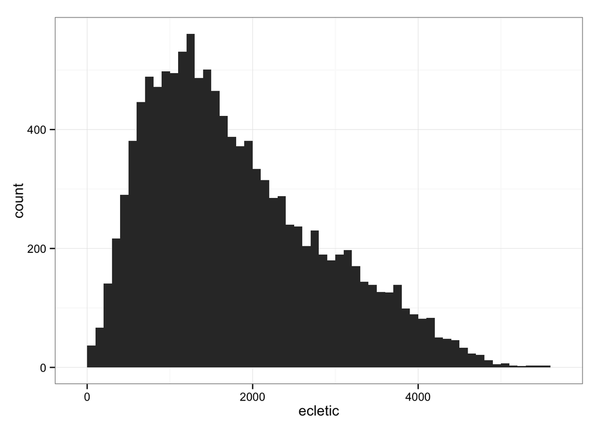

```r
lastfm %>% ggplot(aes(ecletic)) + geom_histogram(binwidth = 100)
```

Imaginemos que essa é a população.